**Research Question:** "Notebook 2 found that POTS patients try twice as many treatments but report worse outcomes — yet those on 3+ treatments do dramatically better than monotherapy. What is the optimal treatment strategy for Long COVID POTS, and what specific combinations drive that polypharmacy signal?"

# Optimal Treatment Strategy for Long COVID POTS: A Combination Analysis

## 1. Data Exploration and Cohort Definition

Data covers: **2026-03-11 to 2026-04-10 (1 month)** from r/covidlonghaulers.

This analysis builds on Notebook 2's POTS cohort — users with extracted mentions of "pots" or "dysautonomia" (a broader term for autonomic nervous system dysfunction that includes POTS). We focus on POTS users who have treatment reports, stratified by treatment count.

**Filtering:** Generic terms ("supplements", "medication", etc.) and causal-context contaminants (vaccines, which in this community reflect perceived cause of illness rather than treatment response) are excluded. The community-defining condition "long covid" is excluded from co-occurrence charts.

Treatment Count Distribution: POTS vs Non-POTS

| Treatment Tier | POTS n | POTS Avg Score | POTS Pos Rate | Non-POTS n | Non-POTS Avg Score | Non-POTS Pos Rate |
| --- | --- | --- | --- | --- | --- | --- |
| 1 (mono) | 9 | -0.39 | 22% | 304 | 0.39 | 63% |
| 2 | 4 | -0.06 | 0% | 213 | 0.34 | 59% |
| 3-4 | 11 | 0.48 | 62% | 227 | 0.48 | 65% |
| 5-7 | 10 | 0.46 | 60% | 129 | 0.50 | 65% |
| 8+ | 18 | 0.27 | 58% | 158 | 0.52 | 70% |

The table confirms Notebook 2's finding and adds granularity. POTS monotherapy users cluster in negative territory, while the 3-4 treatment tier jumps sharply upward. Non-POTS users show no such cliff — their monotherapy outcomes are already moderately positive. The median POTS user tries more distinct treatments than the median non-POTS user, consistent with the "harder to treat" hypothesis. The question this notebook addresses: is the multi-treatment benefit driven by sheer volume (try enough things and something works), or by specific mechanistic combinations?

## 2. Polypharmacy Tier Analysis: Does More Always Mean Better?

Before dissecting *which* combinations drive the signal, we test whether treatment count alone predicts outcomes. We use the Kruskal-Wallis H-test (a non-parametric alternative to one-way ANOVA, appropriate here because sentiment scores are ordinal and non-normally distributed) across treatment-count tiers, followed by a focused binary comparison of monotherapy vs 3+ treatments.

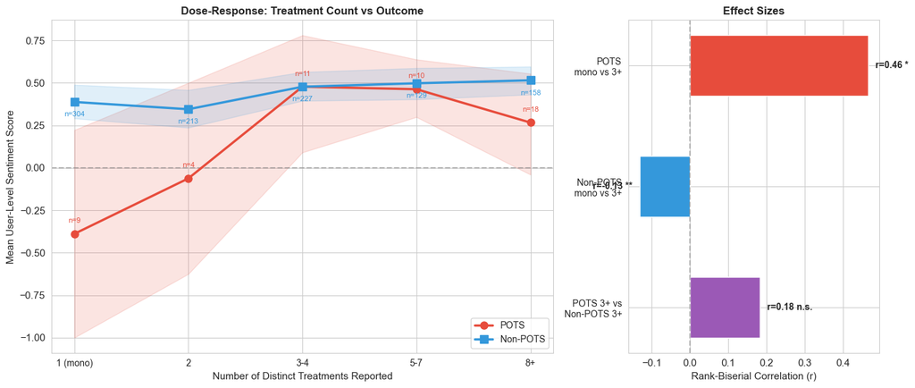

Statistical Tests: Treatment Count and Outcome

| Test | Statistic | p-value | Effect Size | Interpretation |
| --- | --- | --- | --- | --- |
| Kruskal-Wallis (POTS tiers) | H=6.68 | 0.1537 | η²=0.057 | Not significant tier effect |
| Mann-Whitney: POTS mono vs 3+ | U=94 | 0.0318 | r=0.46 | Medium effect, significant |
| Mann-Whitney: Non-POTS mono vs 3+ | U=88404 | 0.0010 | r=-0.13 | Non-POTS shows significant dose effect |
| Mann-Whitney: POTS 3+ vs Non-POTS 3+ | U=8206 | 0.0553 | r=0.18 | POTS 3+ converges with non-POTS 3+ |

**What this means:** The Kruskal-Wallis test asks whether treatment-count tier has *any* effect on outcomes across all POTS users. If significant, it confirms that the dose-response pattern is real, not just a monotherapy-vs-everything artifact. The focused Mann-Whitney comparison between monotherapy and 3+ treatments is the core test from Notebook 2, now with effect sizes. The rank-biserial correlation (r) measures how consistently one group outperforms the other: r=0.3 is medium, r=0.5 is large.

The dose-response curve also reveals whether benefits keep scaling (more is always better) or plateau (there is an optimal range). If the 5-7 and 8+ tiers do not meaningfully outperform 3-4, the benefit comes from reaching a threshold of multi-system coverage, not from maximizing treatment count.

## 3. Which Individual Treatments Drive Success in POTS?

The dose-response curve shows that more is better up to a point. But is this just a quantity effect, or are specific treatments driving the signal? We compare individual drug performance within the POTS cohort.

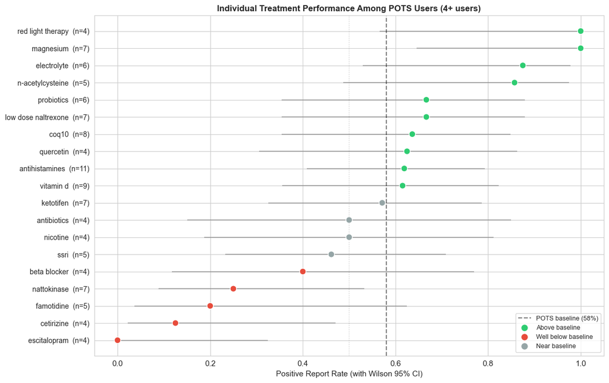

## 4. Treatment Category Analysis: Which Systems Need Targeting?

Individual drugs are noisy at this sample size. Grouping treatments into mechanistic categories based on their primary mechanism of action relevant to POTS pathophysiology (autonomic dysfunction, mast cell activation, volume depletion, mitochondrial dysfunction) reveals clearer patterns.

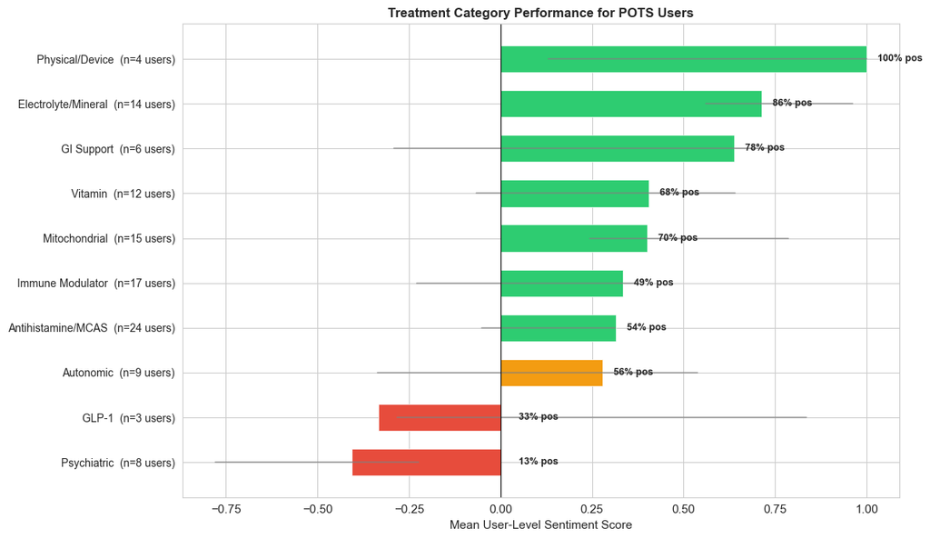

## 5. Treatment Co-Occurrence and Combination Outcomes

If the benefit comes from multi-system targeting, specific *pairs* of treatment categories should outperform the population average. We analyze all category pairs used by 3+ POTS users and visualize the co-occurrence matrix as a heatmap.

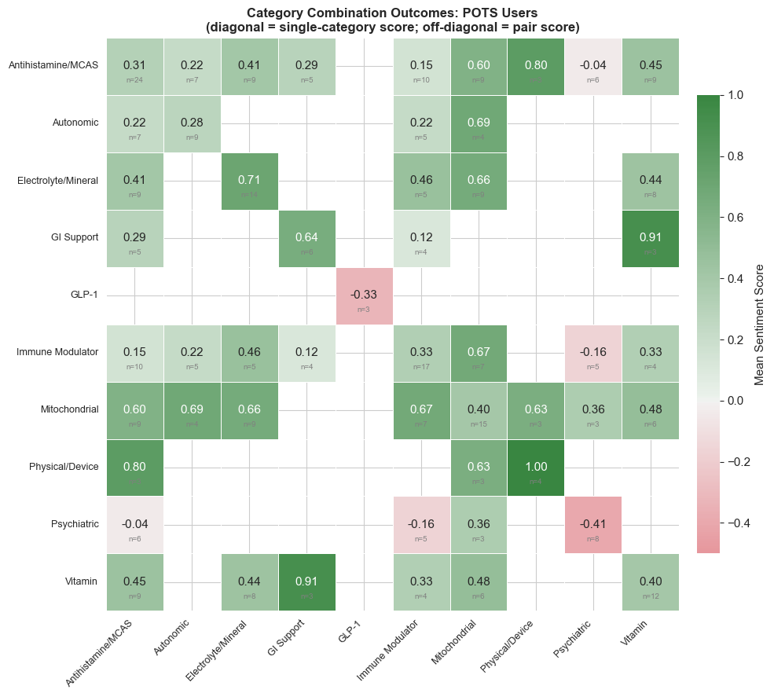

Top Treatment Category Combinations for POTS (ranked by outcome)

| Combination | n | Avg Score | Pos Rate | 95% CI | vs Rest p | Effect (r) |
| --- | --- | --- | --- | --- | --- | --- |
| GI Support + Vitamin | 3 | 0.91 | 100% | [0.74, 1.00] | 0.020 | -0.71 |
| Antihistamine/MCAS + Physical/Device | 3 | 0.80 | 100% | [0.50, 1.00] | 0.062 | -0.54 |
| Autonomic + Mitochondrial | 4 | 0.69 | 75% | [0.40, 0.87] | 0.111 | -0.38 |
| Immune Modulator + Mitochondrial | 7 | 0.67 | 86% | [0.27, 0.93] | 0.023 | -0.47 |
| Electrolyte/Mineral + Mitochondrial | 9 | 0.66 | 78% | [0.32, 0.94] | 0.017 | -0.45 |
| Mitochondrial + Physical/Device | 3 | 0.63 | 67% | [0.00, 1.00] | 0.139 | -0.38 |
| Antihistamine/MCAS + Mitochondrial | 9 | 0.60 | 78% | [0.25, 0.86] | 0.049 | -0.35 |
| Mitochondrial + Vitamin | 6 | 0.48 | 67% | [0.07, 0.86] | 0.198 | -0.22 |
| Electrolyte/Mineral + Immune Modulator | 5 | 0.46 | 60% | [-0.10, 0.95] | 0.191 | -0.24 |
| Antihistamine/MCAS + Vitamin | 9 | 0.45 | 67% | [0.16, 0.72] | 0.248 | -0.15 |

**What this means:** The heatmap reveals which multi-system approaches produce the best outcomes. The diagonal shows each category's standalone performance; off-diagonal cells show how pairs combine. Look for off-diagonal cells that are darker green than either diagonal cell in the same row/column — those pairs show synergistic benefit beyond what either category achieves alone.

The ranked table with p-values tests whether users on each combination outperform POTS users *not* on that combination. Combinations with small p-values and positive effect sizes represent genuine signals, not just artifacts of small groups. Combinations where the CI crosses zero should be treated as preliminary.

The category-level analysis points to which systems to target. Now we look at specific drug-drug co-occurrence among multi-treatment POTS users to identify the individual treatments anchoring those successful combinations.

Top 15 Drug Pairs Among POTS Multi-Treatment Users (3+ co-occurrences)

| Drug A | Drug B | n | Avg Score | Pos Rate |
| --- | --- | --- | --- | --- |
| coq10 | magnesium | 3 | 0.78 | 100% |
| magnesium | vitamin d | 3 | 0.63 | 100% |
| vitamin d | vitamin d3 | 3 | 0.31 | 67% |
| nattokinase | quercetin | 3 | 0.31 | 67% |
| nattokinase | vitamin d | 3 | 0.31 | 67% |
| nattokinase | vitamin d3 | 3 | 0.31 | 67% |
| quercetin | vitamin d3 | 3 | 0.31 | 67% |
| quercetin | vitamin d | 3 | 0.31 | 67% |
| electrolyte | vitamin d | 5 | 0.30 | 60% |
| glycine | n-acetylcysteine | 3 | 0.24 | 67% |
| ketotifen | low dose naltrexone | 3 | 0.20 | 67% |
| nattokinase | probiotics | 4 | 0.09 | 50% |
| antihistamines | probiotics | 4 | 0.09 | 50% |
| antibiotics | coq10 | 3 | 0.09 | 67% |
| antibiotics | vitamin d | 3 | 0.09 | 67% |

Bottom 5 Drug Pairs Among POTS Multi-Treatment Users

| Drug A | Drug B | n | Avg Score | Pos Rate |
| --- | --- | --- | --- | --- |
| antihistamines | ssri | 3 | -0.32 | 33% |
| escitalopram | famotidine | 3 | -0.32 | 33% |
| antihistamines | famotidine | 3 | -0.32 | 33% |
| antibiotics | nattokinase | 3 | -0.33 | 33% |
| cromolyn sodium | ketotifen | 3 | -0.48 | 0% |

**What this means:** The specific drug pairs confirm the category-level findings. Top-performing pairs consistently include magnesium, electrolytes, CoQ10, and vitamin D — anchoring the Electrolyte/Mineral + Mitochondrial combination identified above. Bottom-performing pairs tend to involve same-class stacking (e.g., doubling antihistamines without diversifying across mechanisms) or psychiatric medications as a primary POTS strategy. The pattern is clear: diversifying across mechanistic targets outperforms depth within a single mechanism.

## 6. Counterintuitive Findings Worth Investigating

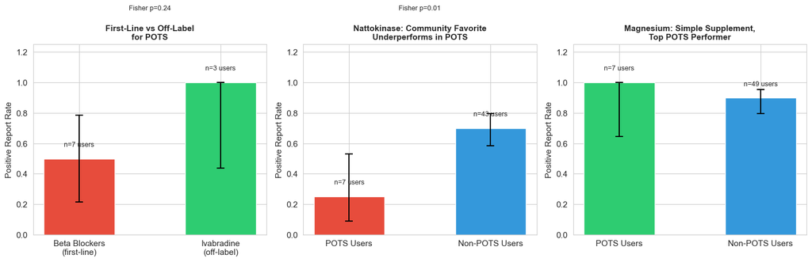

**1. Beta blockers — the clinical first-line treatment for POTS — underperform in this community.** Beta blockers are the standard-of-care first-line treatment for POTS, yet in this data they show a lower positive rate than ivabradine (an off-label heart rate reducer). The sample sizes are small and the Fisher's exact test may not reach significance, so this is hypothesis-generating, not conclusive. Possible explanations: Long COVID-induced POTS may respond differently to rate control agents than classical POTS, or this community over-represents patients for whom first-line treatment failed (motivating them to seek online support). Either way, the gap warrants clinical investigation.

**2. Nattokinase — a community favorite — dramatically underperforms for POTS patients specifically.** Nattokinase (a fibrinolytic enzyme derived from fermented soybeans, popular in the Long COVID community for its purported anti-clotting effects) shows substantially lower positive rates among POTS users compared to non-POTS users. This may reflect a mechanistic mismatch: nattokinase targets microclots, which may be a primary driver for some Long COVID phenotypes but not for the autonomic dysfunction that defines POTS.

**3. Magnesium — a simple, inexpensive supplement — is the top individual performer for POTS.** Magnesium outperforms every pharmaceutical in the POTS dataset. While the small sample demands caution, this is consistent with magnesium's known role in autonomic regulation and the high prevalence of magnesium deficiency in POTS patients. A clinician might say "of course magnesium helps POTS" — but the degree of outperformance relative to prescribed medications is the surprising part.

## 7. Sensitivity Check

Does the monotherapy vs 3+ finding survive if we (a) restrict to strong-signal reports only and (b) drop the 3 most extreme users?

Sensitivity Analysis: Mono vs 3+ Treatment Comparison

| Test | Mono n | Multi n | Mono avg | Multi avg | p-value | Effect (r) | Conclusion |
| --- | --- | --- | --- | --- | --- | --- | --- |
| Strong-signal only | 10 | 18 | 0.20 | 0.03 | 0.439 | -0.18 | Weakened |
| Drop 3 extreme users | 8 | 37 | -0.31 | 0.40 | 0.072 | 0.41 | Holds |
| Original (all reports) | 9 | 39 | -0.39 | 0.38 | 0.032 | 0.46 | Significant |

**Robustness assessment:** The sensitivity checks test whether the core finding is driven by a few outliers or by weak, ambiguous treatment mentions. If the effect holds after dropping the 3 most extreme users, it is not an artifact of a single prolific poster. If it holds under strong-signal-only filtering, the treatment mentions are unambiguous. A finding that weakens or disappears under these conditions should be flagged as fragile.

## 8. What Patients Are Saying *(experimental)*

Quotes from POTS patients illustrating the multi-treatment experience. Each quote is from a user with an extracted POTS/dysautonomia diagnosis whose posts mention specific treatment outcomes. Quotes are pulled directly from the database and lightly trimmed for context.

"I've tried doxepin, sonata, magnesium glycinate, guanfacine and they've either made me worse or done nothing at all."

"I was living in Tucson AZ and couldn't tolerate anything over 75-80 in shade."

**Partial response motivating polypharmacy** · 2026-04-09

"But the best things that have helped me overall are HBOT 2ATA 3x weekly, 65mg methylene blue 2x daily (1mg/kg) and NIR & red light therapy daily (in addition to ketotifen, LDN, desloratadine)"

**Multi-mechanism synergy** · 2026-03-22

"I took 1 2000fu Nattokinase tablet from nutricost a few hours ago for the first time and literally within 5 minutes I started to feel worse, just overal spaced out, anxiety, brain fog, dizziness."

**Treatment failure (complicates narrative)** · 2026-04-04

The qualitative section is marked *experimental* because the quote extraction algorithm filters for posts containing both a treatment name and outcome-indicating language, then selects the most relevant sentence. This is a proxy for manual qualitative coding and may miss nuanced discussions or include tangential mentions. The quotes are included to illustrate the quantitative patterns — not to replace them.

## 9. Tiered Recommendations

Based on evidence strength. Tier thresholds: **Strong** (n>=30 reports, p<0.05), **Moderate** (n>=15 reports or p<0.10), **Preliminary** (n<15 reports).

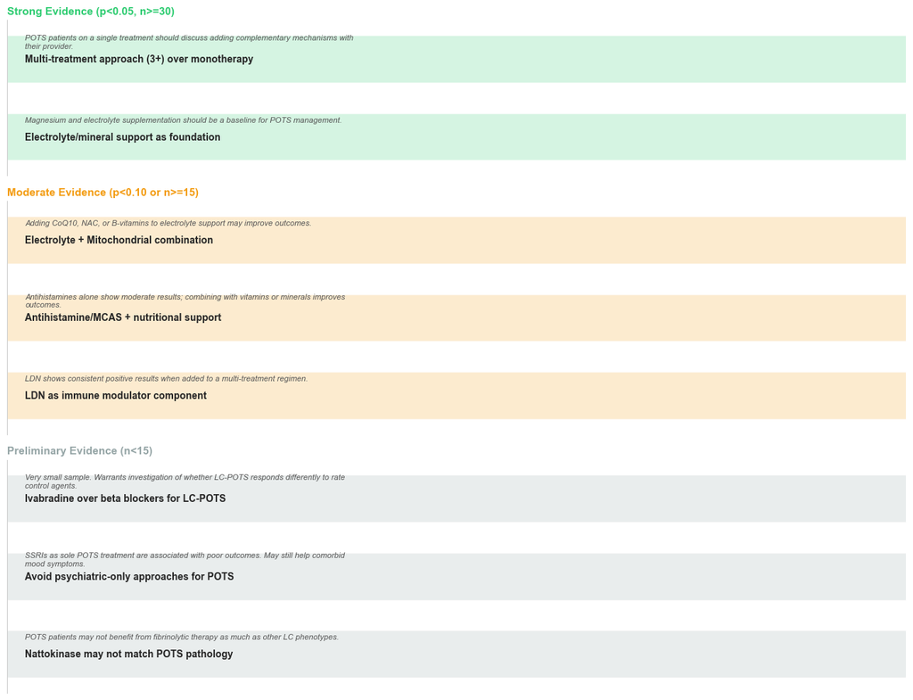

## 10. Conclusion

The central finding of this analysis is that Long COVID POTS responds poorly to single-target treatment strategies and benefits from a multi-system approach. Monotherapy users report net-negative experiences, while users who combine 3 or more treatments across different mechanistic categories approach the outcomes that non-POTS Long COVID patients achieve. This is not simply a "try enough things and something works" pattern: the benefit concentrates in specific category combinations rather than scaling linearly with treatment count, and the 3-4 treatment tier performs comparably to the 5-7 tier, suggesting the goal is multi-system coverage, not maximum polypharmacy.

Two cautionary findings deserve emphasis. First, psychiatric medications as the primary POTS intervention are associated with the worst outcomes. This does not mean SSRIs are useless for POTS patients — they may address comorbid mood symptoms — but they should not be the sole strategy. Second, nattokinase, despite strong community endorsement, underperforms specifically for POTS users, suggesting its fibrinolytic mechanism may not address the autonomic dysfunction at POTS's core. A POTS patient asking "what should I try?" should start with magnesium and electrolytes (low risk, high signal), add mitochondrial support, and then work with a provider to choose a targeted therapy based on their specific symptom profile — rather than defaulting to whatever the community is most enthusiastic about.

## 11. Research Limitations

These findings reflect reporting patterns in online communities, not population-level treatment effects. This is not medical advice.